# Examining background gene lists in clusterProfiler - RNA-seq example

Mark Ziemann & Anusuiya Bora

2024-06-05

Source: https://github.com/markziemann/background

## Introduction

This guide is a Rmarkdown script that conducts differential expression and enrichment analysis, which are very popular workflows for transcriptome data.

In the code chunk below called `libs`, you can add and remove required R library dependancies. Check that the libraries listed here match the Dockerfile, otherwise you might get errors.

```r
suppressPackageStartupMessages({
  library("getDEE2")
  library("DESeq2")
  library("kableExtra")
  library("clusterProfiler")
  library("fgsea")
  library("eulerr")
  library("gplots")
  library("parallel")
})
```

For this guide I will be using bulk RNA-seq data from several previous studies.

## Load data

Gene sets were obtained from MSigDB.

```r
myfiles <- list.files("../dataprep",pattern="*Rds",full.names=TRUE)
d <- lapply(myfiles,readRDS)
names(d) <- basename(myfiles)

mygmts <- list.files("../gmt",pattern="*gmt",full.names=TRUE)
gs <- lapply(mygmts,gmtPathways)
names(gs) <- basename(mygmts)

names(gs)
```

```
## [1] "c2.cp.kegg_medicus.v2023.2.Hs.symbols.gmt"
## [2] "c2.cp.reactome.v2023.2.Hs.symbols.gmt"
## [3] "c2.cp.wikipathways.v2023.2.Hs.symbols.gmt"
## [4] "c3.mir.mirdb.v2023.2.Hs.symbols.gmt"
## [5] "c3.tft.gtrd.v2023.2.Hs.symbols.gmt"
## [6] "c5.go.v2023.2.Hs.symbols.gmt"
## [7] "c5.hpo.v2023.2.Hs.symbols.gmt"
## [8] "c8.all.v2023.2.Hs.symbols.gmt"
## [9] "h.all.v2023.2.Hs.symbols.gmt"
```

```r
names(gs) <- c("KEGG", "Reactome", "Wikipathways", "miR targets", "TFT GTRD",
  "GO", "HPO", "Cellmarkers", "Hallmark" )
```

## Basic geneset analysis

```r
# number of sets
lapply(gs,length)
```

```
## $KEGG
## [1] 619
##
## $Reactome
## [1] 1692
##
## $Wikipathways
## [1] 791
##
## $`miR targets`
## [1] 2377
##
## $`TFT GTRD`
## [1] 505
##
## $GO
## [1] 10461
##
## $HPO
## [1] 5547
##
## $Cellmarkers
## [1] 830
##
## $Hallmark
## [1] 50
```

```r
# set size summary
lapply(gs,function(x) {
  y <- unlist(lapply(x, length ))
  summary(y)
} )
```

```
## $KEGG
##    Min. 1st Qu.  Median    Mean 3rd Qu.    Max.
##    5.00    8.00   13.00   15.59   19.00   92.00
##
## $Reactome
##    Min. 1st Qu.  Median    Mean 3rd Qu.    Max.
##    5.00   11.00   23.00   56.28   57.00 1463.00
##
## $Wikipathways
##    Min. 1st Qu.  Median    Mean 3rd Qu.    Max.
##    5.00   14.00   28.00   42.92   53.00  438.00
##
## $`miR targets`
##    Min. 1st Qu.  Median    Mean 3rd Qu.    Max.
##     5.0    59.0   103.0   156.5   186.0  1071.0
##
## $`TFT GTRD`
##    Min. 1st Qu.  Median    Mean 3rd Qu.    Max.
##     5.0    55.0   287.0   509.3   880.0  1999.0
##
## $GO
##    Min. 1st Qu.  Median    Mean 3rd Qu.    Max.
##    5.00    9.00   18.00   79.83   55.00 1994.00
##
## $HPO
##    Min. 1st Qu.  Median    Mean 3rd Qu.    Max.
##    5.00   10.00   23.00   91.32   74.00 1735.00
##
## $Cellmarkers
##    Min. 1st Qu.  Median    Mean 3rd Qu.    Max.
##     5.0    52.0   115.0   180.5   223.2  1770.0
##
## $Hallmark
##    Min. 1st Qu.  Median    Mean 3rd Qu.    Max.
##    32.0    98.0   180.0   146.4   200.0   200.0
```

```r
# gene coverage
lapply(gs,function(x) {
  y <- unique(unlist(x))
  length(y)
} )
```

```
## $KEGG
## [1] 2727
##
## $Reactome
## [1] 11155
##
## $Wikipathways
## [1] 8313
##
## $`miR targets`
## [1] 16655
##
## $`TFT GTRD`
## [1] 26807
##
## $GO
## [1] 19428
##
## $HPO
## [1] 4997
##
## $Cellmarkers
## [1] 20418
##
## $Hallmark
## [1] 4384
```

```r
# total number of annotations
lapply(gs, function(x) {
  sum(unlist(lapply(x,length)))
} )
```

```
## $KEGG
## [1] 9651
##
## $Reactome
## [1] 95226
##
## $Wikipathways
## [1] 33947
##
## $`miR targets`
## [1] 372061
##
## $`TFT GTRD`
## [1] 257181
##
## $GO
## [1] 835146
##
## $HPO
## [1] 506552
##
## $Cellmarkers
## [1] 149827
##
## $Hallmark
## [1] 7322
```

## Enrichment with Clusterprofiler

Here is a function that conducts over-representation analysis with ClusterProfiler. Genes that are not annotated as having any gene set category are discarded.

```r
# df = deseq output
# df must have "ensID geneSymbol" as rownames

# gs = gene sets
# gs format is list of symbols
orabad <- function( df, gs ) {

  def <- df

  gs1 <- stack(gs)
  colnames(gs1) <- c("gene","term")
  gs1 <- gs1[,c(2,1)]

  defup <- rownames(subset(def,padj<=0.05 & log2FoldChange>0))
  defup <- defup[lapply(strsplit(defup," "),length)==2]
  defup <- unique(sapply(strsplit(defup," "),"[[",2))

  if ( length(defup)<250 ) {
    defup <- head(rownames(subset(def,log2FoldChange>0)),250)
    defup <- defup[lapply(strsplit(defup," "),length)==2]
    defup <- unique(sapply(strsplit(defup," "),"[[",2))
  }

  defdn <- rownames(subset(def,padj<=0.05 & log2FoldChange<0))
  defdn <- defdn[lapply(strsplit(defdn," "),length)==2]
  defdn <- unique(sapply(strsplit(defdn," "),"[[",2))

  if ( length(defdn)<250 ) {
    defdn <- head(rownames(subset(def,log2FoldChange<0)),250)
    defdn <- defdn[lapply(strsplit(defdn," "),length)==2]
    defdn <- unique(sapply(strsplit(defdn," "),"[[",2))
  }

  bg <- rownames(def)
  bg <- bg[lapply(strsplit(bg," "),length)==2]
  bg <- unique(sapply(strsplit(bg," "),"[[",2))

  ora_up <- as.data.frame(enricher(gene = defup ,
    universe = bg, minGSSize = 5, maxGSSize = 500000, TERM2GENE = gs1,
    pAdjustMethod="fdr",  pvalueCutoff = 1, qvalueCutoff = 1  ))

  ora_up$geneID <- NULL
  ora_ups <- rownames(ora_up)

  gr <- as.numeric(sapply(strsplit(ora_up$GeneRatio,"/"),"[[",1)) /
    as.numeric(sapply(strsplit(ora_up$GeneRatio,"/"),"[[",2))

  br <- as.numeric(sapply(strsplit(ora_up$BgRatio,"/"),"[[",1)) /
    as.numeric(sapply(strsplit(ora_up$BgRatio,"/"),"[[",2))

  ora_up$es <- gr/br
  ora_up <- ora_up[order(-ora_up$es),]
  ora_up$Description=NULL

  ora_dn <- as.data.frame(enricher(gene = defdn ,
    universe = bg, minGSSize = 5, maxGSSize = 500000, TERM2GENE = gs1,
    pAdjustMethod="fdr",  pvalueCutoff = 1, qvalueCutoff = 1  ))

  ora_dn$geneID <- NULL
  ora_dns <- rownames(ora_dn)

  gr <- as.numeric(sapply(strsplit(ora_dn$GeneRatio,"/"),"[[",1)) /
    as.numeric(sapply(strsplit(ora_dn$GeneRatio,"/"),"[[",2))

  br <- as.numeric(sapply(strsplit(ora_dn$BgRatio,"/"),"[[",1)) /
    as.numeric(sapply(strsplit(ora_dn$BgRatio,"/"),"[[",2))

  ora_dn$es <- gr/br
  ora_dn <- ora_dn[order(-ora_dn$es),]
  ora_dn$Description=NULL

  result <- list("orabad_up"=ora_up,"orabad_dn"=ora_dn)
  return(result)
}
```

This function fixes the problem with excluding un-annotated genes.

```r
oragood <- function( df, gs ) {

  def <- df

  gs1 <- stack(gs)
  colnames(gs1) <- c("gene","term")
  gs1 <- gs1[,c(2,1)]

  defup <- rownames(subset(def,padj<=0.05 & log2FoldChange>0))
  defup <- defup[lapply(strsplit(defup," "),length)==2]
  defup <- unique(sapply(strsplit(defup," "),"[[",2))

  if ( length(defup)<250 ) {
    defup <- head(rownames(subset(def,log2FoldChange>0)),250)
    defup <- defup[lapply(strsplit(defup," "),length)==2]
    defup <- unique(sapply(strsplit(defup," "),"[[",2))
  }

  defdn <- rownames(subset(def,padj<=0.05 & log2FoldChange<0))
  defdn <- defdn[lapply(strsplit(defdn," "),length)==2]
  defdn <- unique(sapply(strsplit(defdn," "),"[[",2))

  if ( length(defdn)<250 ) {
    defdn <- head(rownames(subset(def,log2FoldChange<0)),250)
    defdn <- defdn[lapply(strsplit(defdn," "),length)==2]
    defdn <- unique(sapply(strsplit(defdn," "),"[[",2))
  }

  bg <- rownames(def)
  bg <- bg[lapply(strsplit(bg," "),length)==2]
  bg <- unique(sapply(strsplit(bg," "),"[[",2))

  bgdf <- data.frame("background",bg)
  names(bgdf) <- c("term","gene")
  gs1 <- rbind(gs1,bgdf)

  ora_up <- as.data.frame(enricher(gene = defup ,
    universe = bg, minGSSize = 5, maxGSSize = 500000, TERM2GENE = gs1,
    pAdjustMethod="fdr",  pvalueCutoff = 1, qvalueCutoff = 1  ))

  ora_up$geneID <- NULL
  ora_ups <- rownames(ora_up)

  gr <- as.numeric(sapply(strsplit(ora_up$GeneRatio,"/"),"[[",1)) /
    as.numeric(sapply(strsplit(ora_up$GeneRatio,"/"),"[[",2))

  br <- as.numeric(sapply(strsplit(ora_up$BgRatio,"/"),"[[",1)) /
    as.numeric(sapply(strsplit(ora_up$BgRatio,"/"),"[[",2))

  ora_up$es <- gr/br
  ora_up <- ora_up[order(-ora_up$es),]
  ora_up$Description=NULL

  ora_dn <- as.data.frame(enricher(gene = defdn ,
    universe = bg, minGSSize = 5, maxGSSize = 500000, TERM2GENE = gs1,
    pAdjustMethod="fdr",  pvalueCutoff = 1, qvalueCutoff = 1  ))

  ora_dn$geneID <- NULL
  ora_dns <- rownames(ora_dn)

  gr <- as.numeric(sapply(strsplit(ora_dn$GeneRatio,"/"),"[[",1)) /
    as.numeric(sapply(strsplit(ora_dn$GeneRatio,"/"),"[[",2))

  br <- as.numeric(sapply(strsplit(ora_dn$BgRatio,"/"),"[[",1)) /
    as.numeric(sapply(strsplit(ora_dn$BgRatio,"/"),"[[",2))

  ora_dn$es <- gr/br
  ora_dn <- ora_dn[order(-ora_dn$es),]
  ora_dn$Description=NULL

  result <- list("oragood_up"=ora_up,"oragood_dn"=ora_dn)
  return(result)
}
```

## Compare the results of bad and good analysis

```r
# bad=ORA analysis, a list with results of up and down regulated pathways
# good=same as bad, except fixed the background problem
compare_ora_plots <- function(bad,good,libname=NULL){
  badup <- bad$orabad_up
  baddn <- bad$orabad_dn
  goodup <- good$oragood_up
  gooddn <- good$oragood_dn
  mup <- merge(badup,goodup,by=0)
  MAX=max(c(mup$es.x,mup$es.y))
  UPHEADER=paste(libname,"up")
  DNHEADER=paste(libname,"dn")

  par(mfrow=c(2,2))

  plot(mup$es.x, mup$es.y,
    xlim=c(0,MAX), ylim=c(0,MAX),
    xlab="original ES", ylab="corrected ES", main=UPHEADER)
  grid()
  abline(a = 0, b = 1,lwd=2,lty=2)

  MAX=max(-log10(c(mup$pvalue.x,mup$pvalue.y)))

  plot(-log10(mup$pvalue.x), -log10(mup$pvalue.y),
    xlim=c(0,MAX), ylim=c(0,MAX),
    xlab="original -log10 p-value", ylab="corrected -log10 p-value", main=UPHEADER)
  grid()
  abline(a = 0, b = 1,lwd=2,lty=2)

  mdn <- merge(baddn,gooddn,by=0)
  MAX=max(c(mdn$es.x,mdn$es.y))

  plot(mdn$es.x, mdn$es.y,
    xlim=c(0,MAX), ylim=c(0,MAX),
    xlab="original ES", ylab="corrected ES", main=DNHEADER)
  grid()
  abline(a = 0, b = 1,lwd=2,lty=2)

  MAX=max(-log10(c(mdn$pvalue.x,mdn$pvalue.y)))

  plot(-log10(mdn$pvalue.x), -log10(mdn$pvalue.y),
    xlim=c(0,MAX), ylim=c(0,MAX),
    xlab="original -log10 p-value", ylab="corrected -log10 p-value", main=DNHEADER)
  grid()
  abline(a = 0, b = 1,lwd=2,lty=2)
}

compare_ora <- function(bad,good){
  badup <- bad$orabad_up
  baddn <- bad$orabad_dn
  goodup <- good$oragood_up
  gooddn <- good$oragood_dn
  mup <- merge(badup,goodup,by=0)
  mdn <- merge(baddn,gooddn,by=0)
  bup <- subset(mup,p.adjust.x<0.05)$Row.names
  gup <- subset(mup,p.adjust.y<0.05)$Row.names
  bdn <- subset(mdn,p.adjust.x<0.05)$Row.names
  gdn <- subset(mdn,p.adjust.y<0.05)$Row.names
  sig_bad <- unique(c(bup,bdn))
  sig_good <- unique(c(gup,gdn))
  nsig_bad <- length(sig_bad)
  nsig_good <- length(sig_good)
  jac <- length(intersect(sig_bad,sig_good)) / length(union(sig_bad,sig_good))
  result=c("nsig_bad"=nsig_bad,"nsig_good"=nsig_good,"jaccard"=jac)
  return(result)
}
```

## Run some analyses

```r
params <- expand.grid(1:length(d),1:length(gs))
params2 <- expand.grid(names(d),names(gs))

colnames(params) <- c("d","gs")

ora_dat <- mclapply(1:nrow(params), function(i) {
  j=params[i,1]
  k=params[i,2]
  bad <- orabad(d[[j]],gs[[k]])
  good <- oragood(d[[j]],gs[[k]])
  res <- compare_ora(bad,good)
  return(res)
} , mc.cores=8)

ora_dat <- do.call(rbind,ora_dat)

res1 <- cbind(params2,ora_dat)

res1 %>%
  kbl(row.names = TRUE, caption="all results") %>%
  kable_paper("hover", full_width = F)
```

all results

|  | Var1 | Var2 | nsig_bad | nsig_good | jaccard |
| --- | --- | --- | --- | --- | --- |
| 1 | bulkrna1.Rds | KEGG | 9 | 19 | 0.4736842 |
| 2 | bulkrna2.Rds | KEGG | 25 | 59 | 0.4237288 |
| 3 | bulkrna3.Rds | KEGG | 2 | 6 | 0.3333333 |
| 4 | bulkrna4.Rds | KEGG | 14 | 24 | 0.5833333 |
| 5 | bulkrna5.Rds | KEGG | 0 | 0 | NaN |
| 6 | bulkrna6.Rds | KEGG | 47 | 56 | 0.8392857 |
| 7 | bulkrna7.Rds | KEGG | 9 | 38 | 0.2368421 |
| 8 | bulkrna1.Rds | Reactome | 64 | 102 | 0.6274510 |
| 9 | bulkrna2.Rds | Reactome | 239 | 351 | 0.6809117 |
| 10 | bulkrna3.Rds | Reactome | 94 | 159 | 0.5617284 |
| 11 | bulkrna4.Rds | Reactome | 207 | 307 | 0.6742671 |
| 12 | bulkrna5.Rds | Reactome | 0 | 0 | NaN |
| 13 | bulkrna6.Rds | Reactome | 254 | 334 | 0.7604790 |
| 14 | bulkrna7.Rds | Reactome | 185 | 240 | 0.7708333 |
| 15 | bulkrna1.Rds | Wikipathways | 33 | 46 | 0.7173913 |
| 16 | bulkrna2.Rds | Wikipathways | 108 | 196 | 0.5510204 |
| 17 | bulkrna3.Rds | Wikipathways | 8 | 12 | 0.6666667 |
| 18 | bulkrna4.Rds | Wikipathways | 13 | 50 | 0.2600000 |
| 19 | bulkrna5.Rds | Wikipathways | 1 | 1 | 1.0000000 |
| 20 | bulkrna6.Rds | Wikipathways | 82 | 97 | 0.8453608 |
| 21 | bulkrna7.Rds | Wikipathways | 35 | 117 | 0.2991453 |
| 22 | bulkrna1.Rds | miR targets | 4 | 81 | 0.0493827 |
| 23 | bulkrna2.Rds | miR targets | 40 | 111 | 0.3603604 |
| 24 | bulkrna3.Rds | miR targets | 21 | 38 | 0.5526316 |
| 25 | bulkrna4.Rds | miR targets | 272 | 634 | 0.4290221 |
| 26 | bulkrna5.Rds | miR targets | 1 | 1 | 1.0000000 |
| 27 | bulkrna6.Rds | miR targets | 1166 | 1365 | 0.8393895 |
| 28 | bulkrna7.Rds | miR targets | 360 | 544 | 0.6617647 |
| 29 | bulkrna1.Rds | TFT GTRD | 52 | 85 | 0.6117647 |
| 30 | bulkrna2.Rds | TFT GTRD | 98 | 140 | 0.7000000 |
| 31 | bulkrna3.Rds | TFT GTRD | 108 | 135 | 0.8000000 |
| 32 | bulkrna4.Rds | TFT GTRD | 72 | 115 | 0.6260870 |
| 33 | bulkrna5.Rds | TFT GTRD | 1 | 1 | 1.0000000 |
| 34 | bulkrna6.Rds | TFT GTRD | 147 | 173 | 0.8497110 |
| 35 | bulkrna7.Rds | TFT GTRD | 129 | 153 | 0.8431373 |
| 36 | bulkrna1.Rds | GO | 485 | 707 | 0.6859972 |
| 37 | bulkrna2.Rds | GO | 1843 | 2168 | 0.8500923 |
| 38 | bulkrna3.Rds | GO | 686 | 915 | 0.7497268 |
| 39 | bulkrna4.Rds | GO | 390 | 707 | 0.5516266 |
| 40 | bulkrna5.Rds | GO | 20 | 65 | 0.3076923 |
| 41 | bulkrna6.Rds | GO | 588 | 789 | 0.7452471 |
| 42 | bulkrna7.Rds | GO | 1263 | 1544 | 0.8180052 |
| 43 | bulkrna1.Rds | HPO | 2 | 42 | 0.0476190 |
| 44 | bulkrna2.Rds | HPO | 380 | 988 | 0.3846154 |
| 45 | bulkrna3.Rds | HPO | 92 | 241 | 0.3817427 |
| 46 | bulkrna4.Rds | HPO | 24 | 296 | 0.0810811 |
| 47 | bulkrna5.Rds | HPO | 0 | 25 | 0.0000000 |
| 48 | bulkrna6.Rds | HPO | 17 | 265 | 0.0641509 |
| 49 | bulkrna7.Rds | HPO | 186 | 449 | 0.4142539 |
| 50 | bulkrna1.Rds | Cellmarkers | 139 | 170 | 0.8176471 |
| 51 | bulkrna2.Rds | Cellmarkers | 439 | 477 | 0.9203354 |
| 52 | bulkrna3.Rds | Cellmarkers | 345 | 382 | 0.9031414 |
| 53 | bulkrna4.Rds | Cellmarkers | 245 | 286 | 0.8566434 |
| 54 | bulkrna5.Rds | Cellmarkers | 0 | 0 | NaN |
| 55 | bulkrna6.Rds | Cellmarkers | 267 | 297 | 0.8989899 |
| 56 | bulkrna7.Rds | Cellmarkers | 448 | 491 | 0.9085366 |
| 57 | bulkrna1.Rds | Hallmark | 7 | 20 | 0.3500000 |
| 58 | bulkrna2.Rds | Hallmark | 25 | 38 | 0.6578947 |
| 59 | bulkrna3.Rds | Hallmark | 18 | 21 | 0.7727273 |
| 60 | bulkrna4.Rds | Hallmark | 13 | 27 | 0.4814815 |
| 61 | bulkrna5.Rds | Hallmark | 0 | 3 | 0.0000000 |
| 62 | bulkrna6.Rds | Hallmark | 28 | 37 | 0.7567568 |
| 63 | bulkrna7.Rds | Hallmark | 18 | 34 | 0.4444444 |

```r
summary(res1$nsig_bad)
```

```
##    Min. 1st Qu.  Median    Mean 3rd Qu.    Max.
##     0.0    13.0    52.0   188.4   242.0  1843.0
```

```r
summary(res1$nsig_good)
```

```
##    Min. 1st Qu.  Median    Mean 3rd Qu.    Max.
##     0.0    35.5   115.0   274.2   320.5  2168.0
```

```r
summary(res1$jaccard)
```

```
##    Min. 1st Qu.  Median    Mean 3rd Qu.    Max.    NA's
##  0.0000  0.4068  0.6598  0.5913  0.8177  1.0000       3
```

```r
# NUMBER OF SIGNIFICANT SETS
ns1 <- matrix( res1$nsig_bad , ncol=9 )
rownames(ns1) <- names(d)
colnames(ns1) <- names(gs)

ns1 %>%
  kbl(row.names = TRUE, caption="significant genesets in original analysis") %>%
  kable_paper("hover", full_width = F)
```

significant genesets in original analysis

|  | KEGG | Reactome | Wikipathways | miR targets | TFT GTRD | GO | HPO | Cellmarkers | Hallmark |
| --- | --- | --- | --- | --- | --- | --- | --- | --- | --- |
| bulkrna1.Rds | 9 | 64 | 33 | 4 | 52 | 485 | 2 | 139 | 7 |
| bulkrna2.Rds | 25 | 239 | 108 | 40 | 98 | 1843 | 380 | 439 | 25 |
| bulkrna3.Rds | 2 | 94 | 8 | 21 | 108 | 686 | 92 | 345 | 18 |
| bulkrna4.Rds | 14 | 207 | 13 | 272 | 72 | 390 | 24 | 245 | 13 |
| bulkrna5.Rds | 0 | 0 | 1 | 1 | 1 | 20 | 0 | 0 | 0 |
| bulkrna6.Rds | 47 | 254 | 82 | 1166 | 147 | 588 | 17 | 267 | 28 |
| bulkrna7.Rds | 9 | 185 | 35 | 360 | 129 | 1263 | 186 | 448 | 18 |

```r
ns1 <- apply(ns1,2,function(x) { x <- x[!is.na(x)] ; x <- x[is.finite(x)] ;  mean(x) } )

ns2 <- matrix( res1$nsig_good , ncol=9 )
rownames(ns2) <- names(d)
colnames(ns2) <- names(gs)

ns2 %>%
  kbl(row.names = TRUE, caption="significant genesets in corrected analysis") %>%
  kable_paper("hover", full_width = F)
```

significant genesets in corrected analysis

|  | KEGG | Reactome | Wikipathways | miR targets | TFT GTRD | GO | HPO | Cellmarkers | Hallmark |
| --- | --- | --- | --- | --- | --- | --- | --- | --- | --- |
| bulkrna1.Rds | 19 | 102 | 46 | 81 | 85 | 707 | 42 | 170 | 20 |
| bulkrna2.Rds | 59 | 351 | 196 | 111 | 140 | 2168 | 988 | 477 | 38 |
| bulkrna3.Rds | 6 | 159 | 12 | 38 | 135 | 915 | 241 | 382 | 21 |
| bulkrna4.Rds | 24 | 307 | 50 | 634 | 115 | 707 | 296 | 286 | 27 |
| bulkrna5.Rds | 0 | 0 | 1 | 1 | 1 | 65 | 25 | 0 | 3 |
| bulkrna6.Rds | 56 | 334 | 97 | 1365 | 173 | 789 | 265 | 297 | 37 |
| bulkrna7.Rds | 38 | 240 | 117 | 544 | 153 | 1544 | 449 | 491 | 34 |

```r
ns2 <- apply(ns2,2,function(x) { x <- x[!is.na(x)] ; x <- x[is.finite(x)] ;  mean(x) } )
ns2
```

```
##         KEGG     Reactome Wikipathways  miR targets     TFT GTRD           GO
##     28.85714    213.28571     74.14286    396.28571    114.57143    985.00000
##          HPO  Cellmarkers     Hallmark
##    329.42857    300.42857     25.71429
```

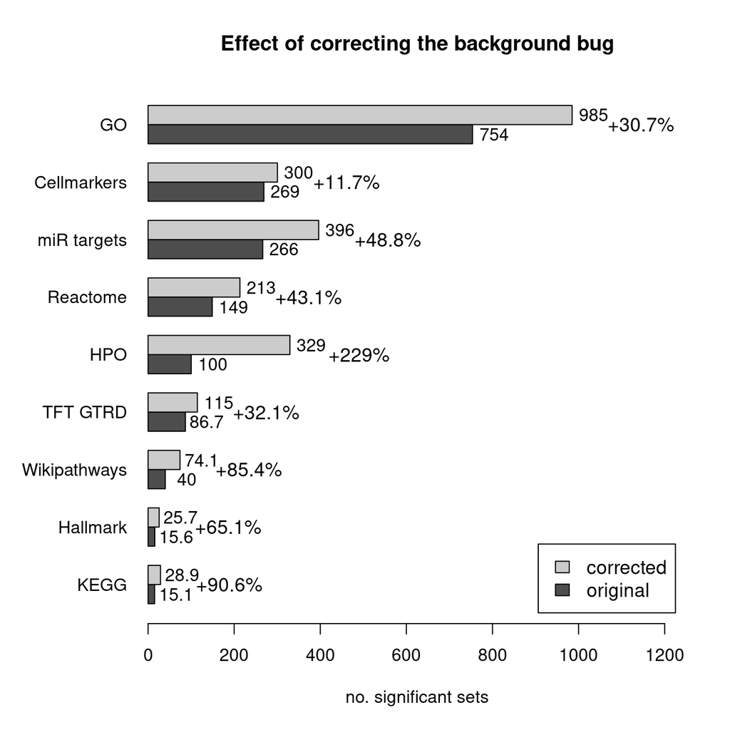

```r
df <- data.frame(ns1,ns2)
df <- df[order(df$ns1),]

par(mar=c(c(5.1, 7.1, 4.1, 2.1) ))
barplot(t(df),beside=TRUE,horiz=TRUE,las=1,xlim=c(0,1250),
  xlab="no. significant sets", main="Effect of correcting the background bug",
  col=c("gray30","gray80"))
text(df$ns1+50,((1:nrow(df))*3)-1.5,labels=signif(df[,1],3))
text(df$ns2+50,((1:nrow(df))*3)-0.5,labels=signif(df[,2],3))
#abline(v=seq(100,1000,100),lty=2,lwd=0.5,col="gray")
legend("bottomright", inset=.02, legend=c("corrected","original"),
  fill=c("gray80","gray30"), horiz=FALSE, cex=1.1)

mylabels <- gsub("$","%",gsub("^","+",signif(((df$ns2/df$ns1)-1)*100,3)))
text(df$ns2+160,((1:nrow(df))*3)-1,labels=mylabels,cex=1.1)
```

```r
# JACCARD
jac <- matrix( res1$jaccard , ncol=9 )
rownames(jac) <- names(d)
colnames(jac) <- names(gs)

signif(jac,3) %>%
  kbl(row.names = TRUE, caption="Jaccard similarity Corrected:Original") %>%
  kable_paper("hover", full_width = F)
```

Jaccard similarity Corrected:Original

|  | KEGG | Reactome | Wikipathways | miR targets | TFT GTRD | GO | HPO | Cellmarkers | Hallmark |
| --- | --- | --- | --- | --- | --- | --- | --- | --- | --- |
| bulkrna1.Rds | 0.474 | 0.627 | 0.717 | 0.0494 | 0.612 | 0.686 | 0.0476 | 0.818 | 0.350 |
| bulkrna2.Rds | 0.424 | 0.681 | 0.551 | 0.3600 | 0.700 | 0.850 | 0.3850 | 0.920 | 0.658 |
| bulkrna3.Rds | 0.333 | 0.562 | 0.667 | 0.5530 | 0.800 | 0.750 | 0.3820 | 0.903 | 0.773 |
| bulkrna4.Rds | 0.583 | 0.674 | 0.260 | 0.4290 | 0.626 | 0.552 | 0.0811 | 0.857 | 0.481 |
| bulkrna5.Rds | NaN | NaN | 1.000 | 1.0000 | 1.000 | 0.308 | 0.0000 | NaN | 0.000 |
| bulkrna6.Rds | 0.839 | 0.760 | 0.845 | 0.8390 | 0.850 | 0.745 | 0.0642 | 0.899 | 0.757 |
| bulkrna7.Rds | 0.237 | 0.771 | 0.299 | 0.6620 | 0.843 | 0.818 | 0.4140 | 0.909 | 0.444 |

```r
jac2 <- apply(jac,2,function(x) { x <- x[!is.na(x)] ; x <- x[is.finite(x)] ;  mean(x) } )
jac2
```

```
##         KEGG     Reactome Wikipathways  miR targets     TFT GTRD           GO
##    0.4817013    0.6792784    0.6199406    0.5560787    0.7758143    0.6726268
##          HPO  Cellmarkers     Hallmark
##    0.1962090    0.8842156    0.4947578
```

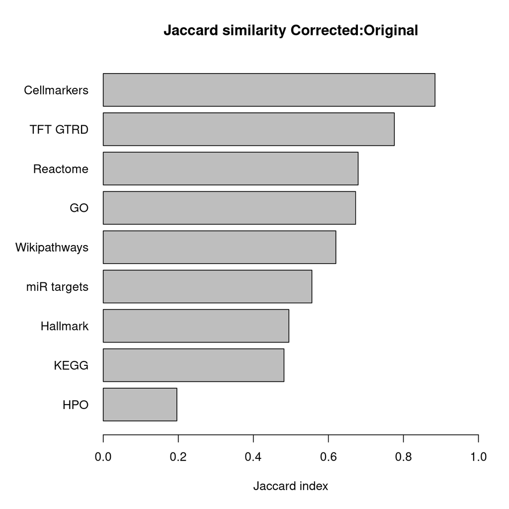

```r
barplot(sort(jac2),horiz=TRUE,las=1,xlim=c(0,1),
  main="Jaccard similarity Corrected:Original",xlab="Jaccard index")
```

## Make charts showing changes in pvalues

For bulk RNA-seq data set #1, run enrichment with all the gene set libraries.

```r
names(gs)
```

```
## [1] "KEGG"         "Reactome"     "Wikipathways" "miR targets"  "TFT GTRD"
## [6] "GO"           "HPO"          "Cellmarkers"  "Hallmark"
```

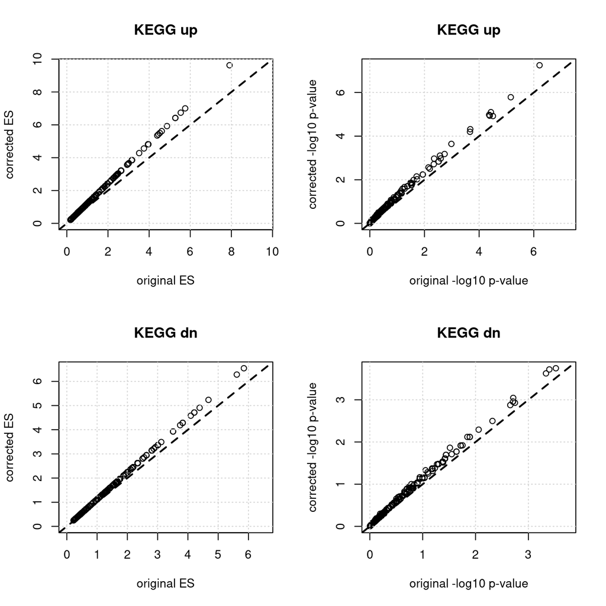

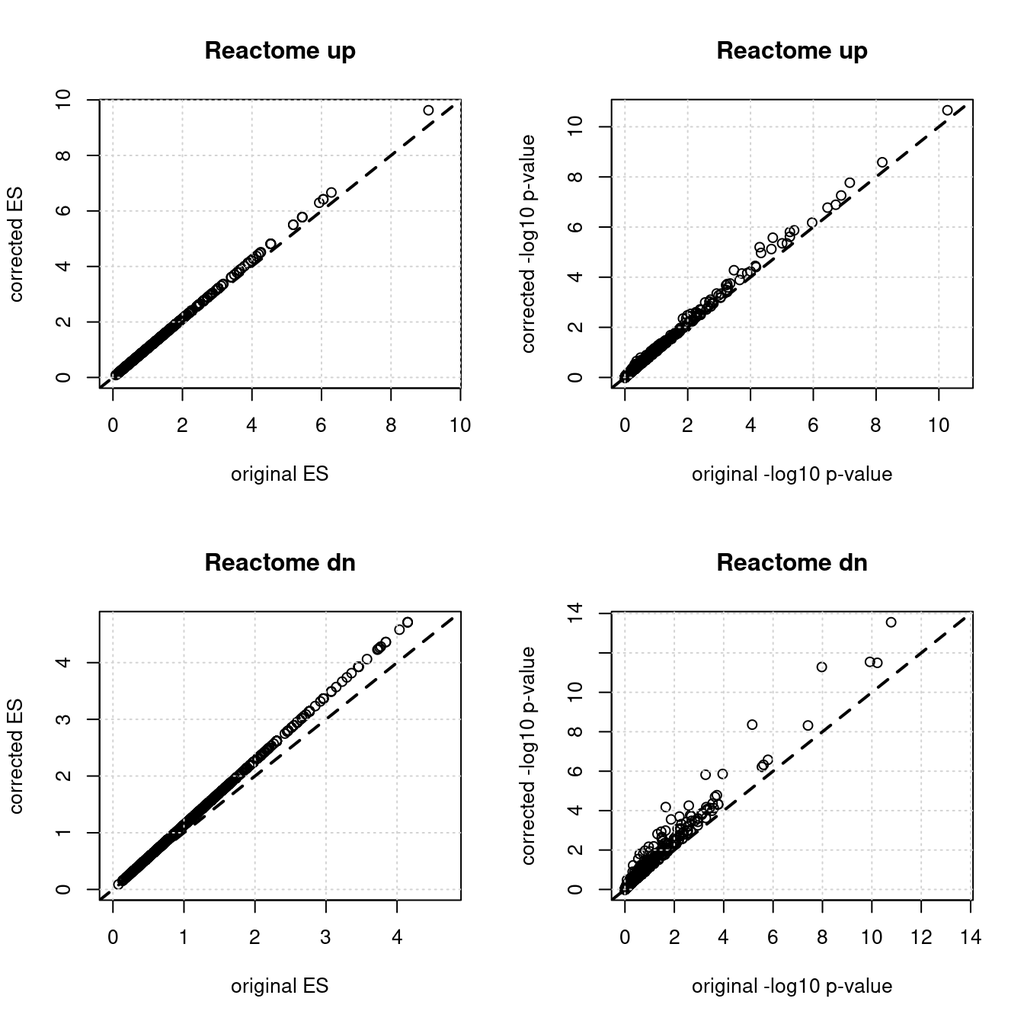

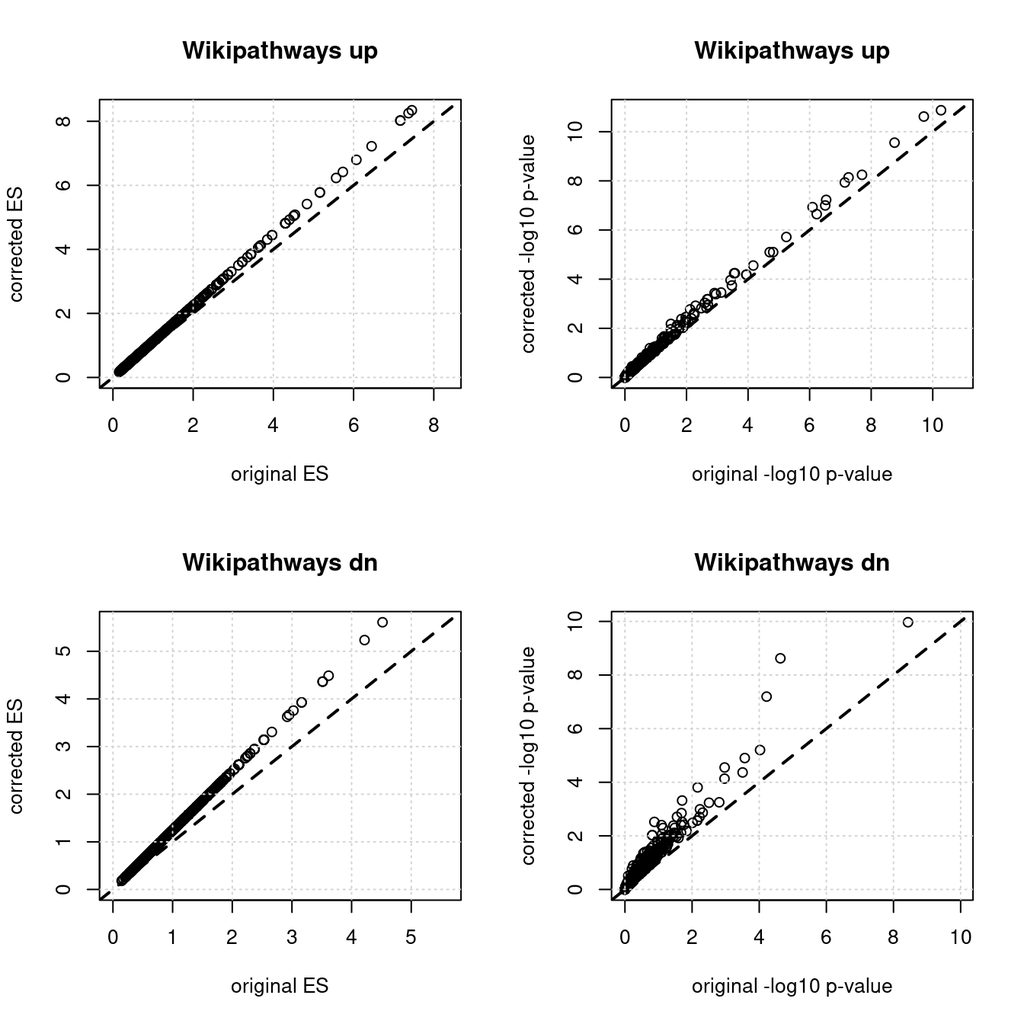

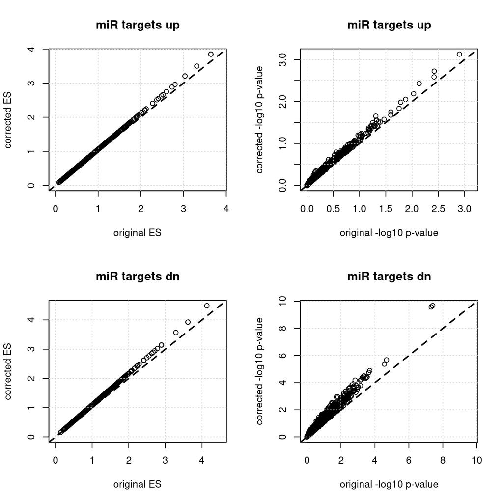

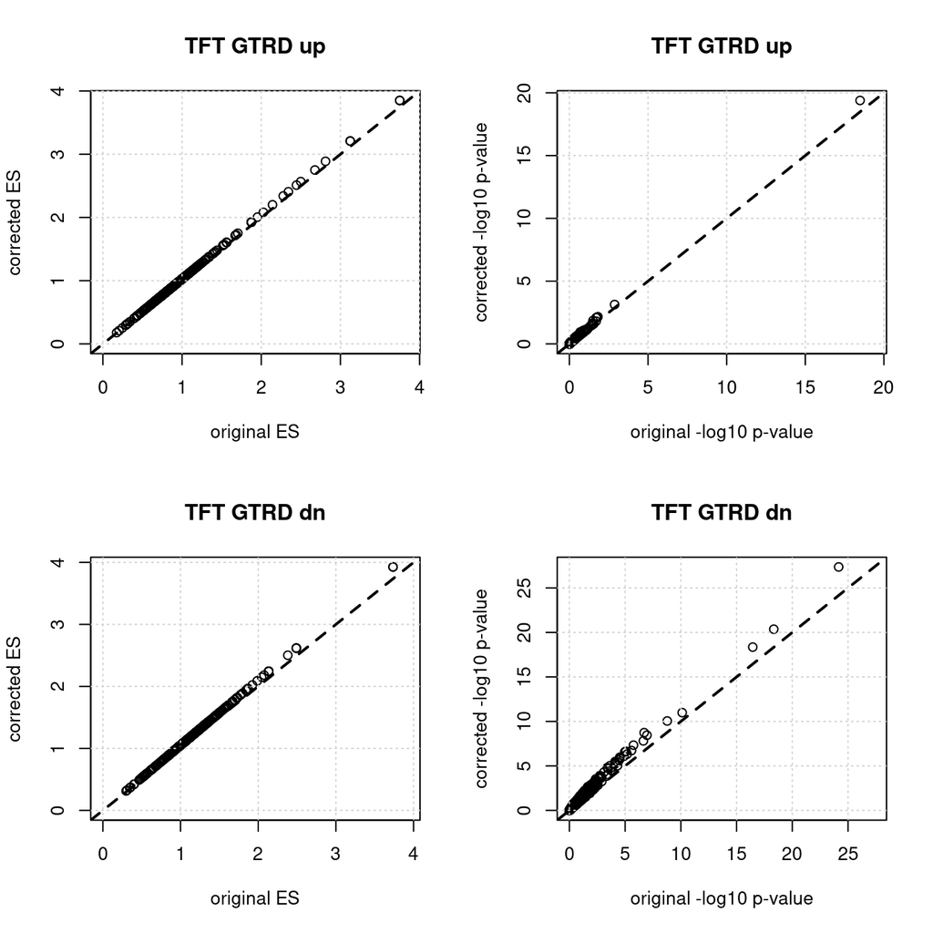

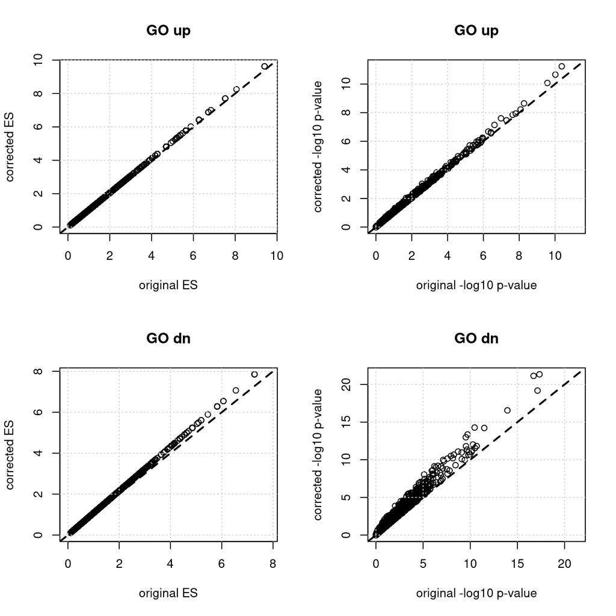

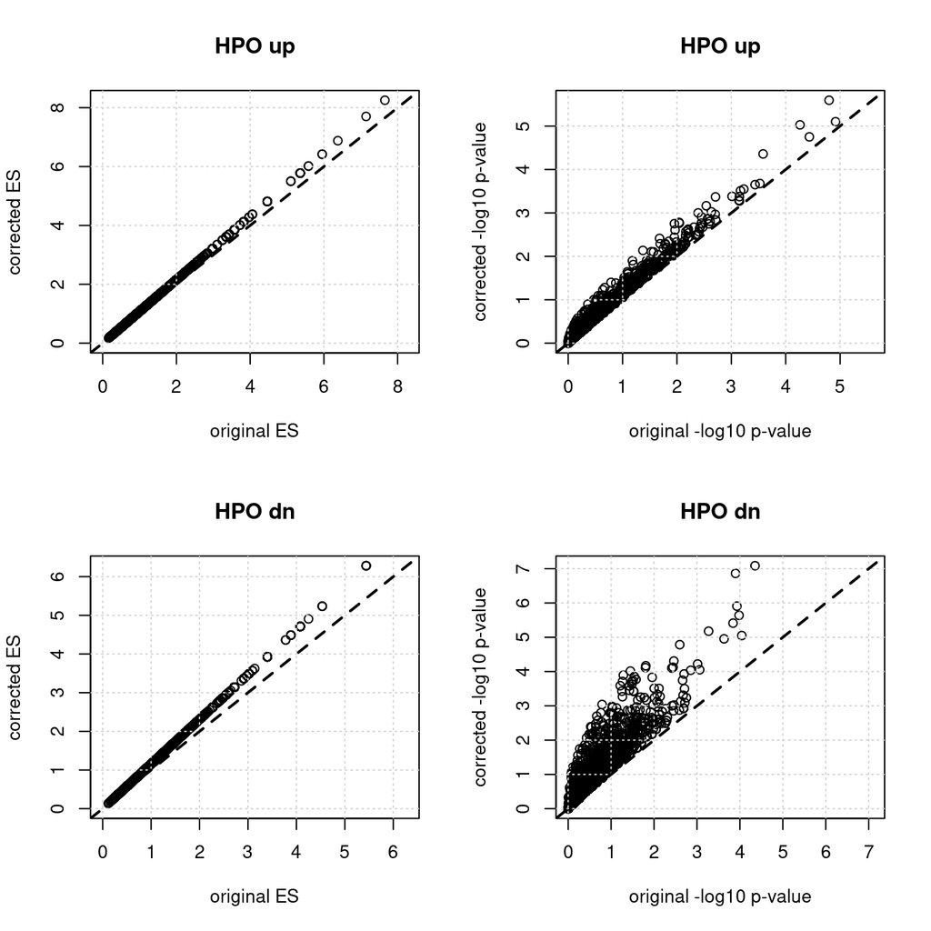

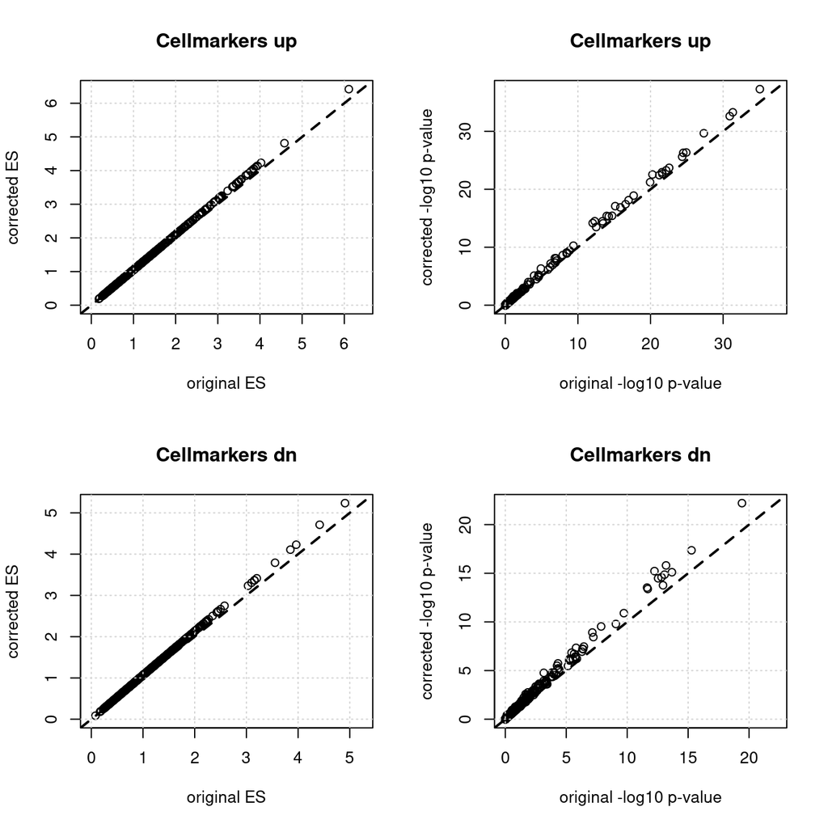

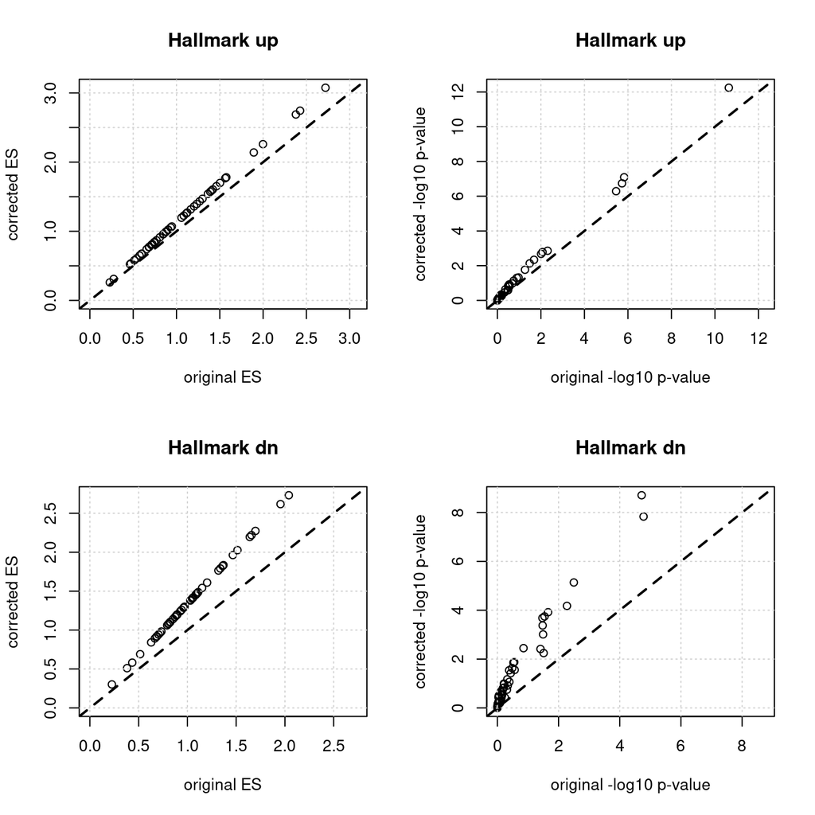

```r
lapply(1:length(gs), function(i) {
  bad <- orabad(d[[1]],gs[[i]])
  good <- oragood(d[[1]],gs[[i]])
  compare_ora_plots(bad,good,libname=names(gs)[i])
} )
```